# report

Quick Scan

Engagement průzkum

Manažerský výstup

Co nás dnes čeká

- 01 Průzkum v číslech
- 02 Výsledky engagementu
- 03 Výsledky jednotlivých driverů
- 04 Otázky, které dopadly hůře
- 05 Multiple choice otázky
- 06 Otevřené otázky
- 07 Závěrečná shrnutí a doporučení

01

Průzkum v číslech

Tato sekce poskytuje základní přehled o průběhu průzkumu ve firmě. Ukážeme Vám např. kolik zaměstnanců se průzkumu zúčastnilo celkově, za jednotlivé organizační jednotky nebo podle demografických údajů.

Průzkum v číslech

30 minut

trvalo průměrně vyplnění dotazníku.

379 lidí

ve vaší firmě odpovědělo na průzkum.

Respondenti podle oddělení

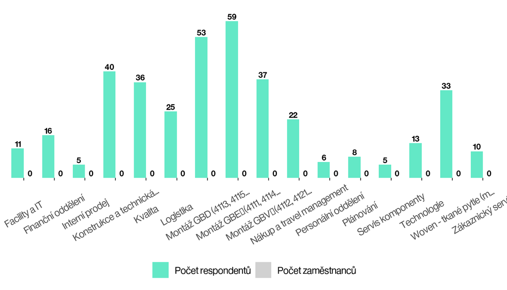

Respondenti podle věku

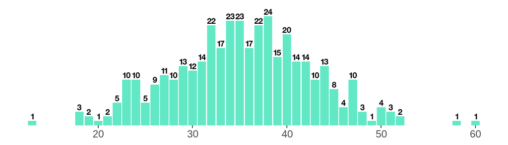

Pracovní pozice

[figure not shown]

Délka působení ve firmě

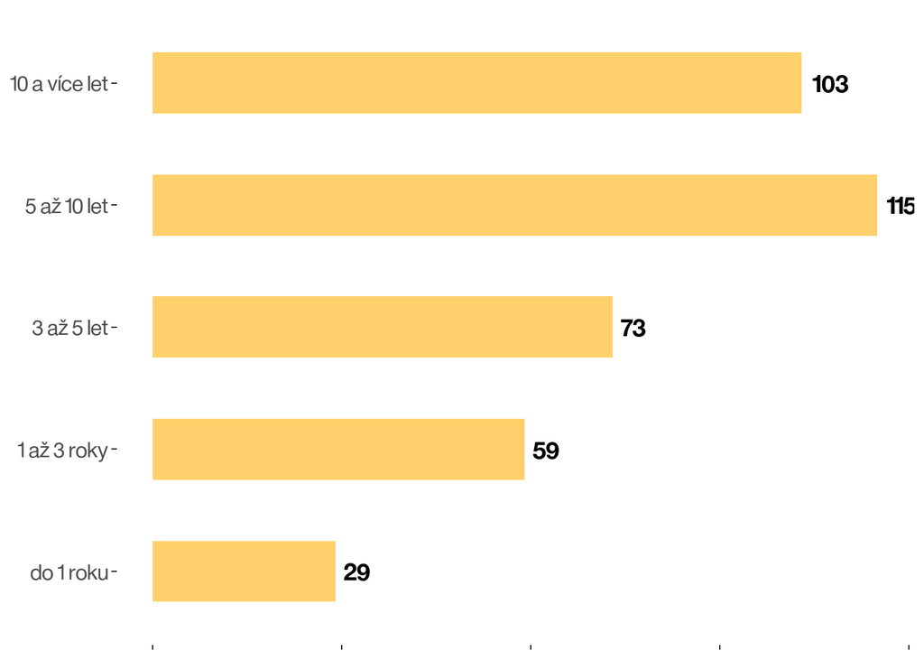

02

Výsledky engagementu

Engagement popisuje vztahy uvnitř firmy. Vztahy mezi zaměstnanci navzájem nebo zaměstnanců k jejich práci. Vyjadřuje, jak moc se člověk dokáže do své práce ponořit, jak pro svou práci/ firmu/kolegy udělá o krok navíc či jednoduše, jak moc jej práce baví a těší.

Engagement je komplexní téma. Právě proto jej měřímě pomocí dvou rozdílných metrik – Engagement indexu a Individuální míry engagementu. Výpočet obou metrik Vám dále vysvětlíme a odprezentujeme.

Metriky engagementu

Každá z engagementových metrik má svůj unikátní záměr, a vyžaduje tak vlastní výpočet i interpetaci. Sledováním Engagement indexu i Individuální míry engagementu získáte komplexnější vhled do celé problematiky a možnost odhalit potenciální problémy, které jeden samostatný ukazatel nedokáže odkrýt.

01

Engagement index

Engagement index je výchozí metrika engagementu v našich výstupech, a má za cíl zmapovat pocity zaměstnanců ohledně jednotlivých aspektů engagementu. Představuje výkon firmy napříč otázkami. Každá odpověď na dílčí otázku může ovlivnit celkovou úroveň engagementu, a proto se také za úplný engagement považuje pouze odpověď Určitě ano. Tato metrika je dále zkoumána napříč odděleními a senioritou zaměstnanců.

02

Individuální míra engagementu

Individuální míra engagementu se zaměřuje na každého zaměstnance zvlášť. Konkrétně na to, jak si vede napříč všemi aspekty engagementu. U každého respondenta se zprůměrují odpovědi na engagementové otázky, a podle toho se zařadí do jedné ze tří skupin – fully engaged, partially engaged nebo disengaged. Na úrovni firmy je důležité sledovat, jaké jsou proporce jednotlivých skupin zaměstnanců a zda se mění v čase.

03

Net promoter score (NPS)

Net promoter score sleduje jednu věc – nakolik je daný zaměstnanec dobrým ambasadorem firmy. Ochota aktivně propagovat svou firmu jako dobré místo pro práci je silně asociovaná i s ostatními aspekty engagementu, a tak skvěle doplňuje obrázek o stavu engagementu ve firmě. Net promoter score dle odpovědi na otázku Doporučil(a) bych tuto firmu jako zaměstnavatele dělí zaměstnance na tři typy – active promoters, neutrals a active detractors.

Jak číst?Engagement index

Tento index ukazuje, jak respondenti reagují na otázku, rozdělený do tří segmentů podle úrovně engagementu.

Engagement index za firmu

Úplný engagement

42 %

Úplný engagement za firmu = 42 %. Toto číslo vyznačuje, kolik % odpovědí na všechny engagementové otázky bylo určitě ano.

Částečný engagement

33 %

Částečný engagement představuje odpovědi, které nejsou zcela jednoznačně pozitivní.

Slabý engagement

25 %

Slabý engagement označuje podíl odpovědí s nízkou mírou zapojení.

Engagement index pro otázku

Škála odpovědí

**Určitě ano** = skóre 1

**Spíše ano** = skóre 2

**Nemohu se rozhodnout** = skóre 3

**Spíše ne** = skóre 4

¨ **Určitě ne** = skóre 5

Jak číst? Individuální míra engagementu

Individuální míra engagementu ukazuje, jak si každý zaměstnanec vede napříč engagementovými otázkami.

Individuální míra engagementu

Úplný engagement

42 %

Engaged zaměstnanec je každý, kdo má průměrné skóre engagementových otázek 1,5 a méně.

Částečný engagement

33 %

Částečně engaged zaměstnanci mají průměr mezi 1,5 a 2,5.

Slabý engagement

25 %

Disengaged zaměstnanci mají průměr vyšší než 2,5.

Příklad:

Respondent odpověděl na engagementové otázky: *Určitě ano, Určitě ano, Spíše ano, Spíše ano*.

Jeho/její průměr = (1+1+2+2)/4 = 1,5.

Respondent patří mezi **engaged** zaměstnance.

Škála odpovědí

**Určitě ano** = skóre 1

**Spíše ano** = skóre 2

**Nemohu se rozhodnout** = skóre 3

**Spíše ne** = skóre 4

**Určitě ne** = skóre 5

Výsledky